# Keyboard Walking Mitigation

## What is it?

Creating a password based on a keyboard pattern rather then memorizing the actual characters

## Why?

- Shitty password policies result in shortcuts
  - See NIST SP800-63b for some modern guidance
- Some people are lazy (like me)
- Easy to meet complex passwords with minimal thought
- Easy to accomodate frequent pasword changes

## What's here?

- Code used for the notebook
- Detecting keyboard walking
- A review against common passwords
- Analysis of impact on several lists
  - English Language Words
  - rockyou.txt
  - Hashcat kwprocessor
  - pwqgen generated passwords
  - Random english word combinations
  - keepassxc generated passwords

## What's missing?

- I didn't find a lot of details on the internet even trying to prevent this so perhaps there is a better resource
- Only english addressed here
- Currently no Unicode or spaces
  - Characters that don't match a standard keyboard character are ignored for the determination
- CSV makes it problematic for pipe separator in passwords
  - Will fix in the future
- A specific implementation
  - Just haven't made it here yet but its in the plans
  - Will be a linux PAM module for the change auth token phase

# The Code

The functions used to graph the data with this Jupyter Notebook

```python
%matplotlib inline
import time
import numpy as np
import pandas
import matplotlib.pyplot as plt
import matplotlib.cm as cm

def bargraph_results(df, word_length=(8, 30), ylim=(0, 100)):
    colors = np.append(plt.cm.Greys(np.linspace(.2, .8, 4)), plt.cm.Reds(np.linspace(.6, .8, 1)), axis=0)
    #colors = plt.cm.Spectral_r(np.linspace(.1, 1, 5))
    f = plt.figure(figsize=(16,8), dpi=100)

    ax1 = f.add_subplot(1, 4, 1)
    ax2 = f.add_subplot(1, 4, 2)
    ax3 = f.add_subplot(1, 4, 3)
    ax4 = f.add_subplot(1, 4, 4)

    # iterate through password lengths
    for i in range(word_length[0], word_length[1]):
        y = []
        #d2 = df[df['word-len'] == i]
        d2 = df[(df['word-len'] == i)]
        count = len(d2)
        if count == 0:
            continue

        last_zero = 0
        last_ones = 0
        last_seq = 0
        # iterate thorugh 10% at a time
        index = 0
        for j in np.arange(0, 1.25, .25):
            y = len(d2[(d2['zeros-ratio'] <= j) & (d2['zeros-ratio'].notna())])
            zero = (y / count) * 100

            y = len(d2[(d2['ones-ratio'] <= j) & (d2['zeros-ratio'].notna())])
            ones = (y / count) * 100

            y = len(d2[(d2['seq-ratio'] <= j) & (d2['zeros-ratio'].notna())])
            seq = (y / count) * 100

            #print(i, j, zero, ones, seq)
            ax1.bar(i, zero - last_zero, bottom=last_zero, color=colors[index], label=j)
            ax2.bar(i, ones - last_ones, bottom=last_ones, color=colors[index], label=j)
            ax3.bar(i, seq - last_seq, bottom=last_seq, color=colors[index], label=j)
            last_zero = zero
            last_ones = ones
            last_seq = seq
            index += 1

        ax1.set_ylabel('Percent')
        ax1.set_ylim(ylim)
        ax1.set_xlabel('Password Length')
        ax1.set_title('Ratio of characters with distance=0')

        ax2.set_ylabel('Percent')
        ax2.set_ylim(ylim)
        ax2.set_xlabel('Password Length')
        ax2.set_title('Ratio of characters with distance=1')

        ax3.set_ylabel('Percent')
        ax3.set_ylim(ylim)
        ax3.set_xlabel('Password Length')
        ax3.set_title('Ratio of characters part of a sequence')

    # Rather then a typical color bar it seemed easier to achieve what I was looking
    # for here with another image lot and some axis manipulation
    ax4.imshow(np.expand_dims(colors, axis=1))
    ax4.set_xticks([])
    ax4.set_yticks(np.arange(0, 1.05, .25) * 4)
    #labels = ['<=%d%%' % (x) for x in np.arange(0, 105, 25)]
    labels = ['0%', '1-25%', '26-50%', '51-75%', '75-100%']
    ax4.set_yticklabels(labels)

    plt.show()

def graph_words(df, zoom=None, word_length=(8, 30), ylim=(0, 100), threshold=.8):
    # default zoom is 1% of the data
    if not zoom:
        zoom = (0, len(df) / 100)
    #colors = np.append(plt.cm.Reds(np.linspace(.1, .8, 8)), plt.cm.Greens(np.linspace(.5, 1, 5)), axis=0)
    colors = np.append(plt.cm.Greys(np.linspace(.1, .8, 5)), plt.cm.Reds(np.linspace(.4, .8, 3)), axis=0)
    #colors = plt.cm.Spectral_r(np.linspace(.1, 1, 20))
    f = plt.figure(figsize=(16,8), dpi=100)
    x = []
    y = []
    zeros = []
    ones = []
    seq = []
    for i in range(word_length[0], word_length[1]):
        d2 = df[df['word-len'] == i]
        count = len(d2)
        if count == 0:
            continue

        zeros.append(len(d2[d2['zeros-ratio'] >= threshold]))
        ones.append(len(d2[d2['ones-ratio'] >= threshold]))
        seq.append(len(d2[d2['seq-ratio'] >= threshold]))

        x.append(i)
        y.append(len(d2))
    ax1 = f.add_subplot(121)
    ax2 = f.add_subplot(122)

    ax1.plot(x, y, marker='.', label='Word Count')
    ax1.plot(x, zeros, marker='.', label='Ratio >= %d%% Zeros Ratio' % (threshold * 100))
    ax1.plot(x, ones, marker='.', label='Ratio >= %d%% Ones Ratio' % (threshold * 100))
    ax1.plot(x, seq, marker='.', label='Ratio >= %d%% Sequence Ratio' % (threshold * 100))
    ax1.set_xlabel('Word Length')
    ax1.set_ylabel('Count')
    ax1.set_yscale('linear')
    ax1.set_ylim(bottom=0)
    ax1.set_title('Words matched by keyboard walking')
    ax1.legend()

    ax2.plot(x, y, marker='.', label='Word Count')
    ax2.plot(x, zeros, marker='.', label='Ratio >= %d%% Zeros Ratio' % (threshold * 100))
    ax2.plot(x, ones, marker='.', label='Ratio >= %d%% Ones Ratio' % (threshold * 100))
    ax2.plot(x, seq, marker='.', label='Ratio >= %d%% Sequence Ratio' % (threshold * 100))
    ax2.set_xlabel('Word Length')
    ax2.set_ylabel('Count')
    ax2.set_yscale('linear')
    ax2.set_ylim(zoom)
    ax2.set_title('Words matched by keyboard walking (Zoomed)')
    ax2.legend()

    plt.show()
```

# Detecting keyboard walking

1. Measure distances
2. Determine proportion of a single value
   - What is the ratio of distances to the number of distances equal to 0?
   - What is the ratio of distances to the number of distances equal to 1?
3. Find sequences in the distances

## Measure Keyboard distances

The first step in detecting keyboard walking is determing how far the travel is. To measure that distance the first character of the password is considered the base and measurements start with the second character.

Distance of 0 is the same key regardless of the shift button so in this case d or D:

[figure not shown]

Distance of 1 is a single left, right, up, or down movement. For the base of d:

[figure not shown]

Distance of 2 is two characters left, right, up, or down or any diagonal key. For the base of d:

[figure not shown]

## Analyze letter distances

Mostly of concern are of 0, 1, or 2 distances.

Most password criteria would reject repeat characters. However, a distance of 0 makes no assumption about the use of the shift key so it's possible to slip past the typical checks.

An example of what might look like a good password but has poor locality:

[figure not shown]

A true "walk" will have a distance of 1 for nearly all characters. A significant number of distances of 1 likely indicates a password walk. The example below has all characters which are distance of 1 and is an obvious keyboard walk.

[figure not shown]

Another example with many keys with a distance of 1 but periodic jumps. It's clear we start to need to look at more then just the distance between adjacent letters.

[figure not shown]

Finally including a distance of 2 may be desirable but generally we it's clear we need more complicated logic.

## Proportion that appears to be a sequence

Since password walking with jumps usually creates sequences we can start to factor in sequences

[figure not shown]

## Finding Sequences

1. Start searching for smallest sequence (2) and increase to largest possible duplicate (number_of_distances / 2)
2. Track the largest ration of characters found a. sequence_size x matches = total_characters b. sequence_ratio = total_characters / number_of_distances

### Example Sequence

**Password: 13qeadzc!#QEADZC**

**Distances: 2,3,2,3,2,3,2,5,2,3,2,3,2,3,2**

[figure not shown]

```
[jeremy@devone keywalk]$ ./keywalk -d test_pass
(0-1) 2 3   match (2-3)
(0-1) 2 3   match (4-5)
(0-1) 2 3   match (8-9)
(0-1) 2 3   match (10-11)
(0-1) 2 3   match (12-13)
new max: total=12 max=1 seqlen=2 match=6
(1-2) 3 2   match (3-4)
(1-2) 3 2   match (5-6)
(1-2) 3 2   match (9-10)
(1-2) 3 2   match (11-12)
(1-2) 3 2   match (13-14)
(2-3) 2 3   match (4-5)
(2-3) 2 3   match (8-9)
(2-3) 2 3   match (10-11)
(2-3) 2 3   match (12-13)
(3-4) 3 2   match (5-6)
(3-4) 3 2   match (9-10)
(3-4) 3 2   match (11-12)
(3-4) 3 2   match (13-14)
(4-5) 2 3   match (8-9)
(4-5) 2 3   match (10-11)
(4-5) 2 3   match (12-13)
(5-6) 3 2   match (9-10)
(5-6) 3 2   match (11-12)
(5-6) 3 2   match (13-14)
(8-9) 2 3   match (10-11)
(8-9) 2 3   match (12-13)
(9-10) 3 2   match (11-12)
(9-10) 3 2   match (13-14)
(10-11) 2 3   match (12-13)
(0-2) 2 3 2   match (4-6)
(0-2) 2 3 2   match (8-10)
(0-2) 2 3 2   match (12-14)
(1-3) 3 2 3   match (9-11)
(2-4) 2 3 2   match (8-10)
(2-4) 2 3 2   match (12-14)
(3-5) 3 2 3   match (9-11)
(4-6) 2 3 2   match (8-10)
(4-6) 2 3 2   match (12-14)
(8-10) 2 3 2   match (12-14)
(0-3) 2 3 2 3   match (8-11)
(1-4) 3 2 3 2   match (9-12)
(2-5) 2 3 2 3   match (8-11)
(3-6) 3 2 3 2   match (9-12)
(0-4) 2 3 2 3 2   match (8-12)
(1-5) 3 2 3 2 3   match (9-13)
(2-6) 2 3 2 3 2   match (8-12)
(0-5) 2 3 2 3 2 3   match (8-13)
(1-6) 3 2 3 2 3 2   match (9-14)
(0-6) 2 3 2 3 2 3 2   match (8-14)
new max: total=14 max=12 seqlen=7 match=2
13qeadzc!#QEADZC|2,3,2,3,2,3,2,5,2,3,2,3,2,3,2|16|15|0.00|0.00|0.93
```

## Common Passwords

20 Most common keyboard patterns according to WPEngine.com (https://wpengine.com/resources/passwords-unmasked-infographic/)

| | | | | :-:|:-:|:-:|:-:

[figure not shown]

|

[figure not shown]

|

[figure not shown]

|

[figure not shown]

|

[figure not shown]

|

[figure not shown]

|

[figure not shown]

|

[figure not shown]

|

[figure not shown]

|

[figure not shown]

|

[figure not shown]

|

[figure not shown]

|

[figure not shown]

|

[figure not shown]

### Effectiveness

While many of these won't meet modern password lengths we can detect the following ratios based on the criteria above:

- Distances of only ones: 6 of 20
- Ratio of ones >= 75%: 14 of 20
- Sequence makes up >= 75% of characters: 18 of 20
- Not matched at all: 2 of 20

There are 2 problematic patterns and neither match a qwerty based keyboard walk that I can see.

The first is more of a construction of the english language and numerics and the second is based on a phone's numeric pattern hitting keys 2 - 9.

| | | | :-:|:-:|:-:

[figure not shown]

|

[figure not shown]

# Review of various word lists

## English Language Words

In order to minimize the impact on the use of good password policies (pass phrases) we would like to minimize the impact on the words in the english language.

```python
tmp = pandas.read_csv('wordlists/results/english.txt_results', sep='|', on_bad_lines='skip', encoding_errors='ignore')
english = tmp[tmp['zeros-ratio'].notna() & tmp['ones-ratio'].notna() & tmp['seq-ratio'].notna()]
print('Valid words: %d' % (len(english)))
english.sample(10)
```

```
Valid words: 466523
```

|  | word | distances | word-len | dist-len | zeros-ratio | ones-ratio | seq-ratio |
| --- | --- | --- | --- | --- | --- | --- | --- |
| 443200 | unwilier | 3,6,6,2,2,5,1 | 8 | 7 | 0.00 | 0.14 | 0.43 |
| 375076 | sonnetization | 8,5,0,5,2,3,9,1,5,3,1,5 | 13 | 12 | 0.08 | 0.17 | 0.42 |
| 43888 | black-mouthed | 5,8,3,6,5,7,4,2,2,2,4,1 | 13 | 12 | 0.00 | 0.08 | 0.42 |
| 207542 | kipped | 1,2,0,7,1 | 6 | 5 | 0.20 | 0.40 | 0.40 |
| 183814 | ICMP | 7,4,5 | 4 | 3 | 0.00 | 0.00 | 0.33 |
| 243595 | monase | 4,5,6,1,2 | 6 | 5 | 0.00 | 0.20 | 0.40 |
| 64645 | cervixes | 2,1,2,6,8,3,2 | 8 | 7 | 0.00 | 0.14 | 0.43 |
| 433955 | Un-jacobean | 3,8,6,6,3,8,6,4,3,6 | 11 | 10 | 0.00 | 0.00 | 0.60 |
| 98302 | deergrass | 1,0,1,2,2,4,1,0 | 9 | 8 | 0.25 | 0.38 | 0.50 |
| 86175 | correctly | 8,5,0,1,2,4,5,4 | 9 | 8 | 0.12 | 0.12 | 0.38 |

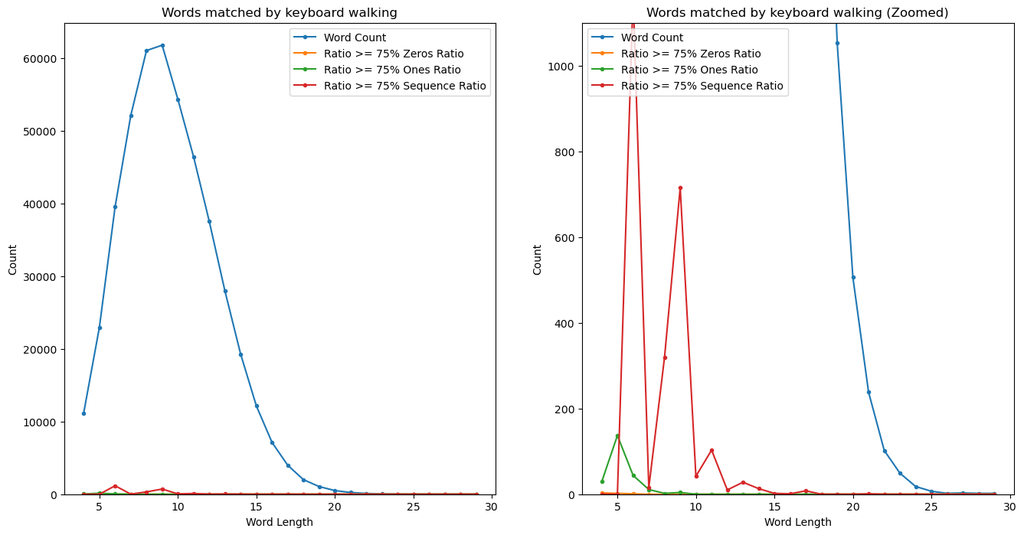

```python
graph_words(english, zoom=(0, 1100), word_length=(4,30), threshold=.75)
```

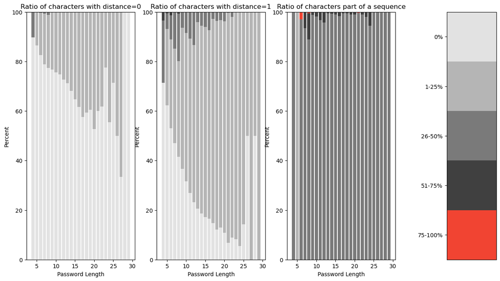

```python
bargraph_results(english, word_length=(4,30))
```

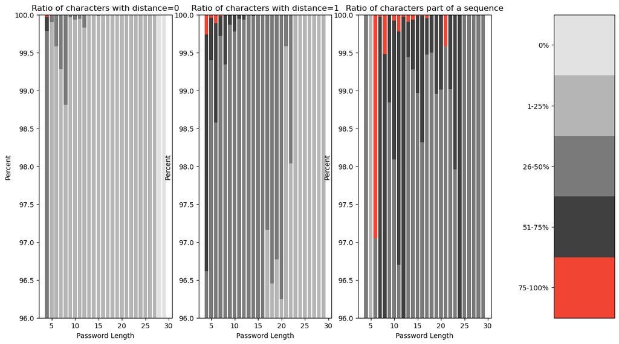

```python
bargraph_results(english, word_length=(4,30), ylim=(96, 100))
```

### Random sample

```python
e1 = english[(english['word-len'] >= 4) & ((english['zeros-ratio'] >= .75) | (english['ones-ratio'] >= .75) | (english['seq-ratio'] >= .75))]
print("%d words that meet at least one of the criter to be flagged" % len(e1))
display(e1.sample(10))
```

```
2629 words that meet at least one of the criter to be flagged
```

|  | word | distances | word-len | dist-len | zeros-ratio | ones-ratio | seq-ratio |
| --- | --- | --- | --- | --- | --- | --- | --- |
| 454351 | wasteries | 2,1,4,2,1,4,5,2 | 9 | 8 | 0.0 | 0.25 | 0.75 |
| 196083 | invading | 4,2,4,2,6,4,2 | 8 | 7 | 0.0 | 0.00 | 0.86 |
| 152165 | gators | 4,5,4,5,3 | 6 | 5 | 0.0 | 0.00 | 0.80 |
| 407950 | Tydeus | 1,4,1,4,6 | 6 | 5 | 0.0 | 0.40 | 0.80 |
| 342112 | roband | 5,6,5,6,4 | 6 | 5 | 0.0 | 0.00 | 0.80 |
| 140153 | fitments | 5,3,4,6,5,3,4 | 8 | 7 | 0.0 | 0.00 | 0.86 |
| 206520 | Khoikhoi | 2,4,1,1,2,4,1 | 8 | 7 | 0.0 | 0.43 | 0.86 |
| 177176 | hypotrich | 1,4,1,4,1,4,7,4 | 9 | 8 | 0.0 | 0.38 | 0.75 |
| 211283 | lamaic | 8,7,7,8,7 | 6 | 5 | 0.0 | 0.00 | 0.80 |
| 345454 | rumpliest | 3,2,5,2,2,5,2,4 | 9 | 8 | 0.0 | 0.00 | 0.75 |

## rockyou.txt

```python
tmp = pandas.read_csv('wordlists/results/rockyou.txt_results', sep='|', on_bad_lines='skip', encoding_errors='ignore')
rockyou = tmp[tmp['zeros-ratio'].notna() & tmp['ones-ratio'].notna() & tmp['seq-ratio'].notna()]
print(len(rockyou))
rockyou.sample(10)
```

```
14340457
```

|  | word | distances | word-len | dist-len | zeros-ratio | ones-ratio | seq-ratio |
| --- | --- | --- | --- | --- | --- | --- | --- |
| 8921694 | crip1930 | 3,4,2,10,8,6,7 | 8 | 7 | 0.00 | 0.00 | 0.43 |
| 7410036 | iloveelmo07 | 2,1,7,3,0,7,3,4,2,3 | 11 | 10 | 0.10 | 0.10 | 0.40 |
| 3230857 | thugess | 2,2,3,3,2,0 | 7 | 6 | 0.17 | 0.00 | 0.33 |
| 6072904 | louiejellytesse | 1,2,1,5,5,5,7,0,4,1,2,2,0,2 | 15 | 14 | 0.14 | 0.21 | 0.43 |
| 1475690 | morece86 | 4,5,1,2,2,6,2 | 8 | 7 | 0.00 | 0.14 | 0.43 |
| 2383374 | 113650 | 0,2,3,1,5 | 6 | 5 | 0.20 | 0.20 | 0.40 |
| 6299202 | leah2020 | 7,3,5,6,8,8,8 | 8 | 7 | 0.00 | 0.00 | 0.43 |
| 12316264 | 4802194 | 4,2,8,1,8,5 | 7 | 6 | 0.00 | 0.17 | 0.33 |
| 7961843 | gamekid64 | 4,7,6,6,1,6,5,2 | 9 | 8 | 0.00 | 0.12 | 0.38 |
| 11911841 | 7349034 | 4,1,5,1,7,1 | 7 | 6 | 0.00 | 0.50 | 0.33 |

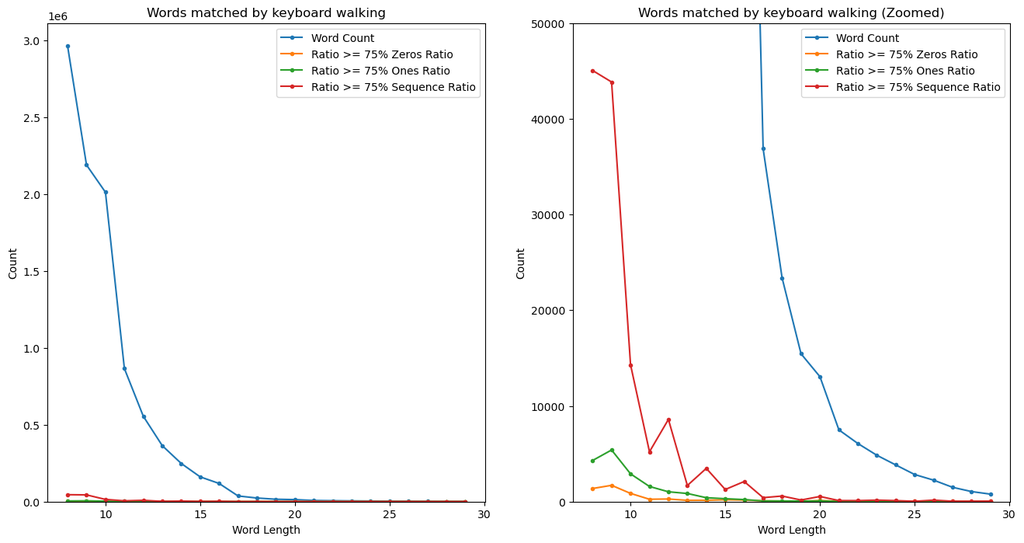

```python
graph_words(rockyou, zoom=(0, 50000), threshold=.75)
```

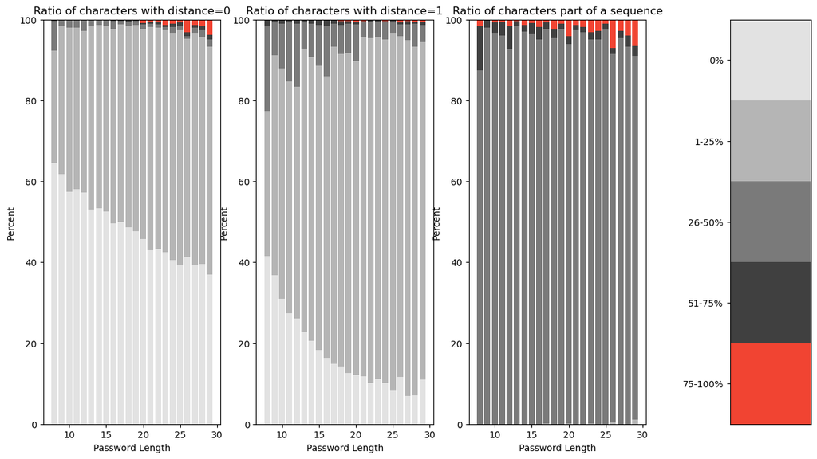

```python
bargraph_results(rockyou)
```

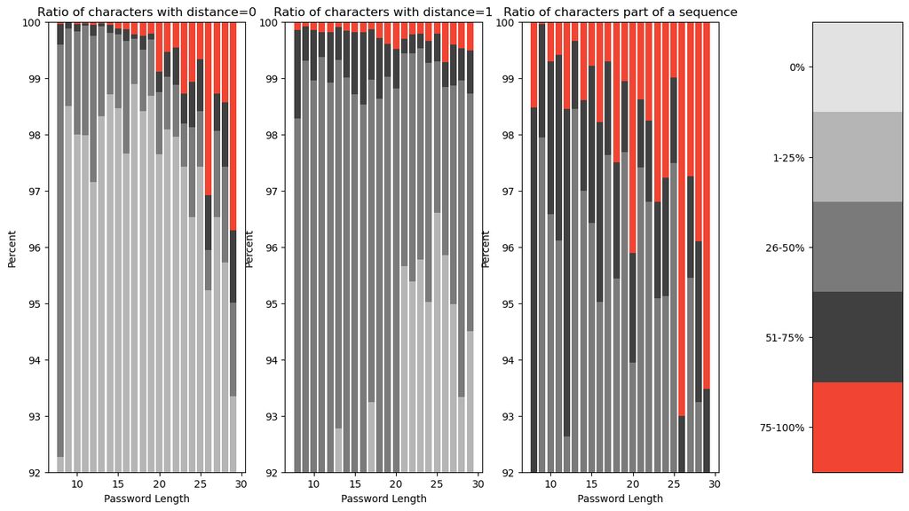

```python
bargraph_results(rockyou, ylim=(92,100))
```

### Random sample

```python
rockyou[(rockyou['dist-len'] > 11) & (rockyou['seq-ratio'] > .75)].sample(10)
```

|  | word | distances | word-len | dist-len | zeros-ratio | ones-ratio | seq-ratio |
| --- | --- | --- | --- | --- | --- | --- | --- |
| 12002288 | 666wales666wales | 0,0,5,2,8,7,2,6,0,0,5,2,8,7,2 | 16 | 15 | 0.27 | 0.00 | 0.93 |
| 6525184 | kkkkkkkhhhhhhh | 0,0,0,0,0,0,2,0,0,0,0,0,0 | 14 | 13 | 0.92 | 0.00 | 0.92 |
| 5942957 | m1111111111111111111111111111111 | 9,0,0,0,0,0,0,0,0,0,0,0,0,0,0,0,0,0,0,0,0,0,0,... | 32 | 31 | 0.97 | 0.00 | 0.97 |
| 12795176 | 2479384424793844 | 2,3,2,6,5,4,0,2,2,3,2,6,5,4,0 | 16 | 15 | 0.13 | 0.00 | 0.80 |
| 13238375 | 145001450014500 | 3,1,5,0,9,3,1,5,0,9,3,1,5,0 | 15 | 14 | 0.21 | 0.21 | 0.86 |
| 10281169 | akoakoakoakoako | 7,2,9,7,2,9,7,2,9,7,2,9,7,2 | 15 | 14 | 0.00 | 0.00 | 0.86 |
| 13412301 | 1112223334445 | 0,0,1,0,0,1,0,0,1,0,0,1 | 13 | 12 | 0.67 | 0.33 | 1.00 |
| 13912432 | 074149479307414947930741494793 | 3,3,3,3,5,5,3,2,6,7,3,3,3,3,5,5,3,2,6,7,3,3,3,... | 30 | 29 | 0.00 | 0.00 | 0.93 |
| 7858312 | gladjiegladjie | 4,8,2,4,2,5,3,4,8,2,4,2,5 | 14 | 13 | 0.00 | 0.00 | 0.92 |
| 10130578 | analeenoanaleen | 6,6,8,7,0,5,5,9,6,6,8,7,0,5 | 15 | 14 | 0.14 | 0.00 | 0.86 |

## Hashcat kwprocessor

**Results from (word-list-2to16-3)**

```python
tmp = pandas.read_csv('wordlists/results/hashcat_kwprocessor.txt_results', sep='|', on_bad_lines='skip', encoding_errors='ignore')
kwprocessor = tmp[tmp['zeros-ratio'].notna() & tmp['ones-ratio'].notna() & tmp['seq-ratio'].notna()]
print(len(kwprocessor))
kwprocessor.sample(10)
```

```
1048524
```

|  | word | distances | word-len | dist-len | zeros-ratio | ones-ratio | seq-ratio |
| --- | --- | --- | --- | --- | --- | --- | --- |
| 322200 | iop:l | 1,1,1,1 | 5 | 4 | 0.0 | 1.0 | 0.25 |
| 489082 | fDSdfghjhgf | 1,1,1,1,1,1,1,1,1,1 | 11 | 10 | 0.0 | 1.0 | 1.00 |
| 369139 | ik,>,mnbvcxz | 1,1,1,1,1,1,1,1,1,1,1 | 12 | 11 | 0.0 | 1.0 | 0.91 |
| 901879 | ertyuioIUiop[] | 1,1,1,1,1,1,1,1,1,1,1,1,1 | 14 | 13 | 0.0 | 1.0 | 0.92 |
| 617103 | vCXZaq1@ | 1,1,1,1,1,1,1 | 8 | 7 | 0.0 | 1.0 | 0.86 |
| 625099 | *&^%TGBvcx | 1,1,1,1,1,1,1,1,1 | 10 | 9 | 0.0 | 1.0 | 1.00 |
| 446619 | uytYUIop[] | 1,1,1,1,1,1,1,1,1 | 10 | 9 | 0.0 | 1.0 | 1.00 |
| 713440 | !@#$%$%^&* | 1,1,1,1,1,1,1,1,1 | 10 | 9 | 0.0 | 1.0 | 1.00 |
| 771894 | zxcvbNM<>?:P) | 1,1,1,1,1,1,1,1,1,1,1,1 | 13 | 12 | 0.0 | 1.0 | 1.00 |
| 728919 | aSDFGfdSA | 1,1,1,1,1,1,1,1 | 9 | 8 | 0.0 | 1.0 | 1.00 |

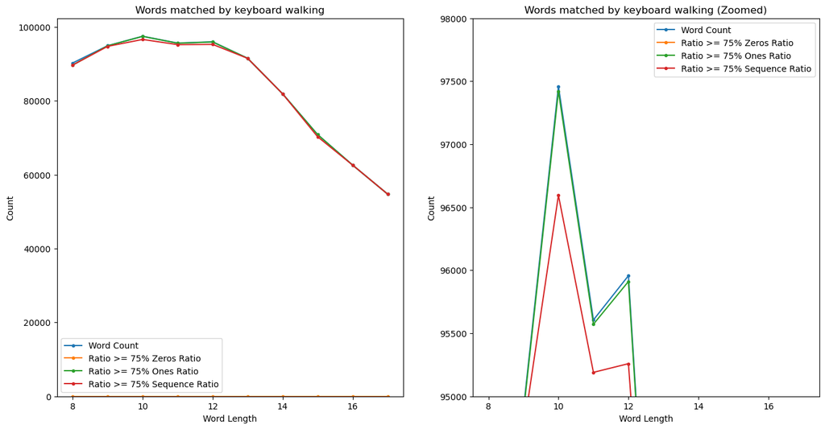

```python
graph_words(kwprocessor, zoom=(95000, 98000), threshold=.75)
```

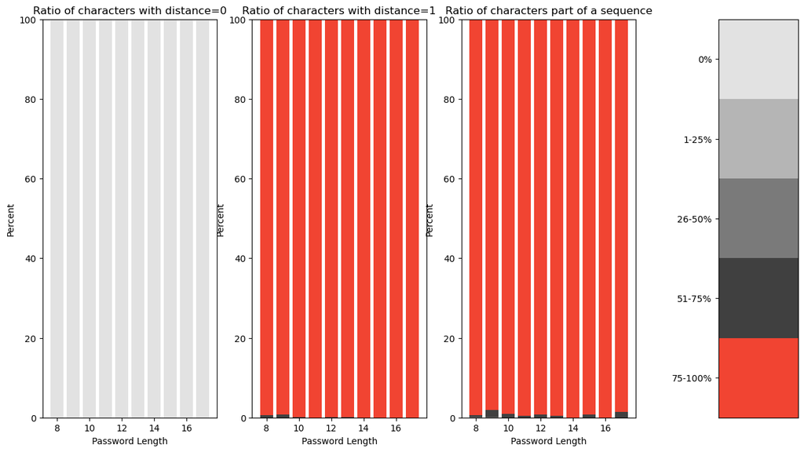

```python
bargraph_results(kwprocessor)
```

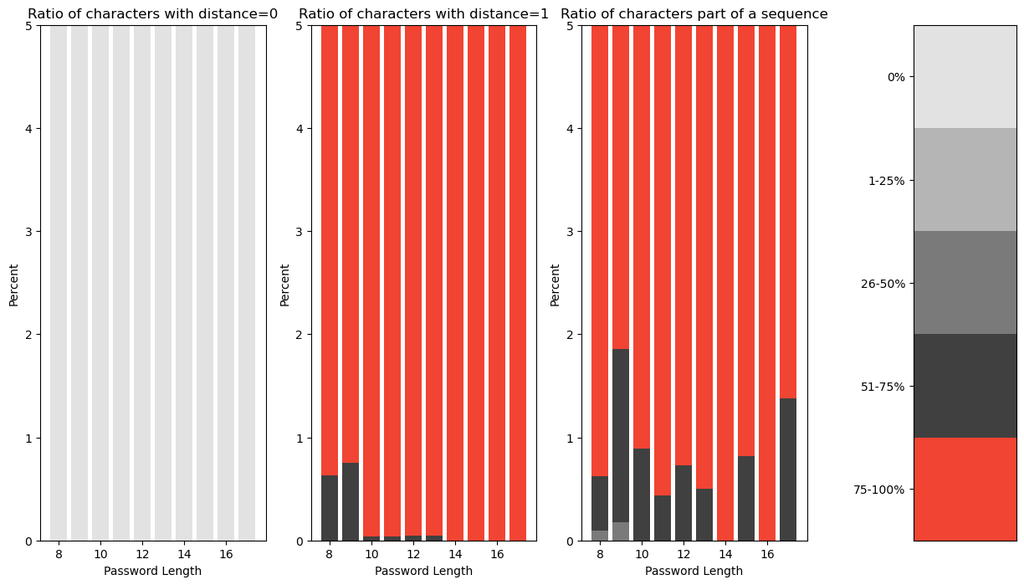

```python
bargraph_results(kwprocessor, ylim=(0,5))
```

### Random sample

```python
kwprocessor[(kwprocessor['dist-len'] >= 8) & (kwprocessor['dist-len'] < 12) & (kwprocessor['seq-ratio'] < .75)].sample(10)
```

|  | word | distances | word-len | dist-len | zeros-ratio | ones-ratio | seq-ratio |
| --- | --- | --- | --- | --- | --- | --- | --- |
| 759954 | REWQ\QWER$ | 1,1,1,12,12,1,1,1,1 | 10 | 9 | 0.0 | 0.78 | 0.67 |
| 284413 | `\qwertyuI | 14,12,1,1,1,1,1,1,1 | 10 | 9 | 0.0 | 0.78 | 0.67 |
| 101004 | 1q\QWERTYUIO | 1,12,12,1,1,1,1,1,1,1,1 | 12 | 11 | 0.0 | 0.82 | 0.73 |
| 160303 | SwQ\qwertyui | 1,1,12,12,1,1,1,1,1,1,1 | 12 | 11 | 0.0 | 0.82 | 0.73 |
| 414102 | xSWQ\qwerty | 1,1,1,12,12,1,1,1,1,1 | 11 | 10 | 0.0 | 0.80 | 0.60 |
| 252317 | 5TREWQ\qwer | 1,1,1,1,1,12,12,1,1,1 | 11 | 10 | 0.0 | 0.80 | 0.60 |
| 467446 | WEREWQ\QW | 1,1,1,1,1,12,12,1 | 9 | 8 | 0.0 | 0.75 | 0.50 |
| 767496 | REWQ\QWERTG | 1,1,1,12,12,1,1,1,1,1 | 11 | 10 | 0.0 | 0.80 | 0.60 |
| 891640 | yTREWQ\QWS | 1,1,1,1,1,12,12,1,1 | 10 | 9 | 0.0 | 0.78 | 0.67 |
| 672370 | EWQ\QWERTYHN | 1,1,12,12,1,1,1,1,1,1,1 | 12 | 11 | 0.0 | 0.82 | 0.73 |

## pwqgen

**Generated 100000 passwords using pwqgen with the following:**

```
[jeremy@devone results]$ for len in $(seq 24 8 96); do seq 1 1000 | xargs -i pwqgen random=$len; done > pwqgen.txt
```

```python
tmp = pandas.read_csv('wordlists/results/pwqgen.txt_results', sep='|', on_bad_lines='skip', encoding_errors='ignore')
pwquality = tmp[tmp['zeros-ratio'].notna() & tmp['ones-ratio'].notna() & tmp['seq-ratio'].notna()]
print(len(pwquality))
pwquality.sample(10)
```

```
100000
```

|  | word | distances | word-len | dist-len | zeros-ratio | ones-ratio | seq-ratio |
| --- | --- | --- | --- | --- | --- | --- | --- |
| 7202 | plane-toward | 2,8,6,5,9,7,4,7,2,4,2 | 12 | 11 | 0.00 | 0.00 | 0.45 |
| 37805 | laden7dogma4own= | 8,2,1,5,4,6,7,5,3,7,5,6,7,6,9 | 16 | 15 | 0.00 | 0.07 | 0.47 |
| 92599 | Hungry6finite&Lest$bone5them!Treaty | 2,3,2,2,2,1,4,5,4,4,3,2,5,4,7,2,4,2,4,6,5,5,3,... | 35 | 34 | 0.00 | 0.15 | 0.47 |
| 81276 | bet+magnum7shire_vacant6whole5quay | 4,2,8,8,7,4,2,3,2,3,7,4,3,4,1,9,10,4,3,3,6,3,2... | 34 | 33 | 0.00 | 0.06 | 0.48 |
| 90829 | bring_Worthy+Save5Calmly7Noise9mean | 3,4,4,2,8,10,7,5,1,2,1,7,12,1,4,3,3,5,3,8,3,3,... | 35 | 34 | 0.00 | 0.12 | 0.47 |
| 58752 | omit$Celery_bonus-Sack | 4,3,3,2,4,2,7,7,1,2,6,9,6,5,3,6,11,11,1,3,6 | 22 | 21 | 0.00 | 0.10 | 0.48 |
| 82247 | lesion5spasm_move!month7stride!whale | 7,2,7,1,5,4,5,9,10,1,6,7,7,4,7,3,3,9,4,5,3,2,3... | 36 | 35 | 0.00 | 0.11 | 0.49 |
| 92994 | Relay_ideal*petrol&Dollar5Glee!gone | 1,7,8,6,6,4,6,1,3,8,3,3,7,2,1,5,1,4,6,7,1,0,8,... | 35 | 34 | 0.06 | 0.15 | 0.47 |
| 74720 | Steady5Posh=rome$breath7onset | 4,2,3,2,4,2,6,1,8,4,8,9,5,4,6,2,4,3,1,3,5,2,3,... | 29 | 28 | 0.00 | 0.07 | 0.46 |
| 88720 | grunt=shed=racket$manor+rump8play | 2,3,3,3,8,12,4,4,1,11,9,4,3,6,6,2,2,6,7,6,5,5,... | 33 | 32 | 0.00 | 0.03 | 0.47 |

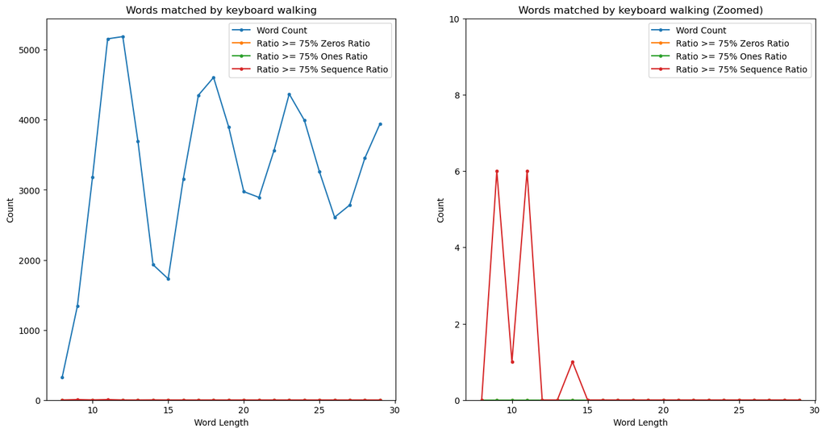

```python
graph_words(pwquality, zoom=(0, 10), threshold=.75)
```

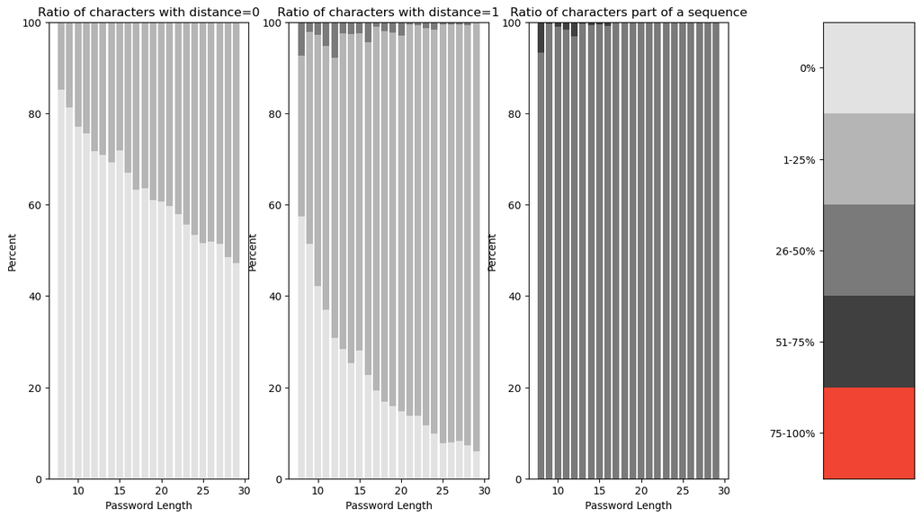

```python
bargraph_results(pwquality)
```

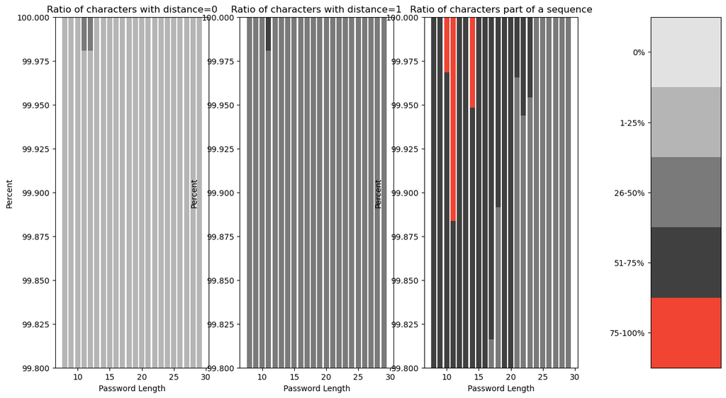

```python
bargraph_results(pwquality, ylim=(99.8,100))
```

### Random sample

```python
pwquality[(pwquality['seq-ratio'] >= .75)].sample(10)
```

|  | word | distances | word-len | dist-len | zeros-ratio | ones-ratio | seq-ratio |
| --- | --- | --- | --- | --- | --- | --- | --- |
| 3083 | futile-limb | 4,2,3,2,7,9,4,2,3,2 | 11 | 10 | 0.00 | 0.00 | 0.80 |
| 13456 | ache3are8 | 3,4,4,1,4,4,1,6 | 9 | 8 | 0.00 | 0.25 | 0.75 |
| 2915 | duet-lice | 5,4,2,7,4,2,7,2 | 9 | 8 | 0.00 | 0.00 | 0.75 |
| 436 | mirth-tight | 3,4,1,2,7,7,3,4,1,2 | 11 | 10 | 0.00 | 0.20 | 0.80 |
| 4506 | lucky-off | 3,6,6,3,6,3,6,0 | 9 | 8 | 0.12 | 0.00 | 0.75 |
| 17945 | begin6inch8 | 4,3,4,4,3,3,4,3,4,4 | 11 | 10 | 0.00 | 0.00 | 0.80 |
| 7305 | scary-pub | 2,3,4,2,6,2,3,4 | 9 | 8 | 0.00 | 0.00 | 0.75 |
| 15695 | curve3turf! | 6,3,2,3,1,3,2,3,1,5 | 11 | 10 | 0.00 | 0.20 | 0.80 |
| 1157 | slate-net | 7,8,5,2,9,8,5,2 | 9 | 8 | 0.00 | 0.00 | 0.75 |
| 5541 | messy-messy | 6,2,0,5,6,7,6,2,0,5 | 11 | 10 | 0.20 | 0.00 | 0.80 |

## Random english word combinations

### Code used

Here is rougly the code used to generate this dataset:

```
output = open('wordlists/random_english_combo.txt', 'w')
filtered = english[(english['word-len'] >= 3) & (english['word-len'] <= 8)]
test = []
for i in range(100000):
    passwd = ''
    for x in filtered.sample(3)['word']:
        passwd += str(x)
    print(passwd, file=output)
output.close()
```

```
10000
```

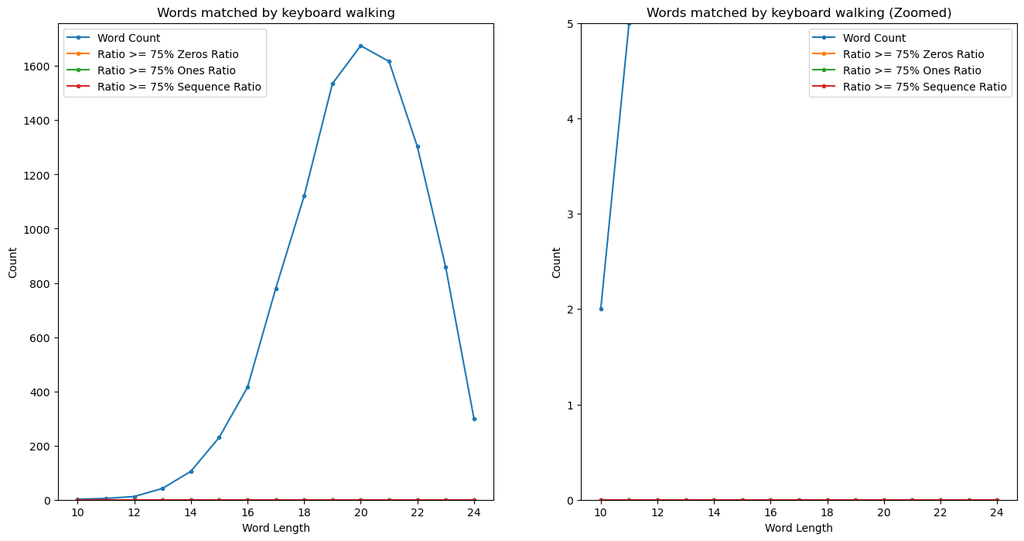

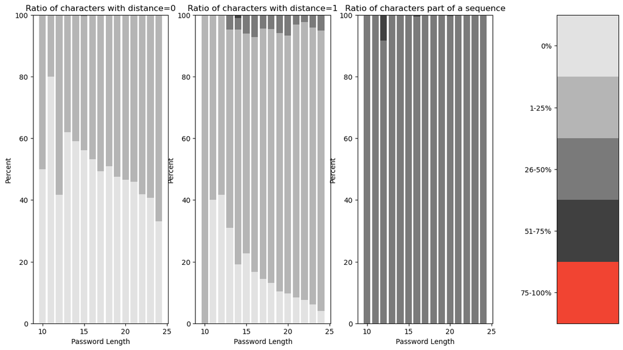

```
0.45863699999999996
```

```python
tmp = pandas.read_csv('wordlists/results/random_english_combo.txt_results', sep='|', on_bad_lines='skip', encoding_errors='ignore')
english_combo = tmp[tmp['zeros-ratio'].notna() & tmp['ones-ratio'].notna() & tmp['seq-ratio'].notna()]
print(len(english_combo))
graph_words(english_combo, zoom=(0, 5), threshold=.75)
bargraph_results(english_combo)
np.mean(english_combo['seq-ratio'])
```

## keepassxc

```
110000
```

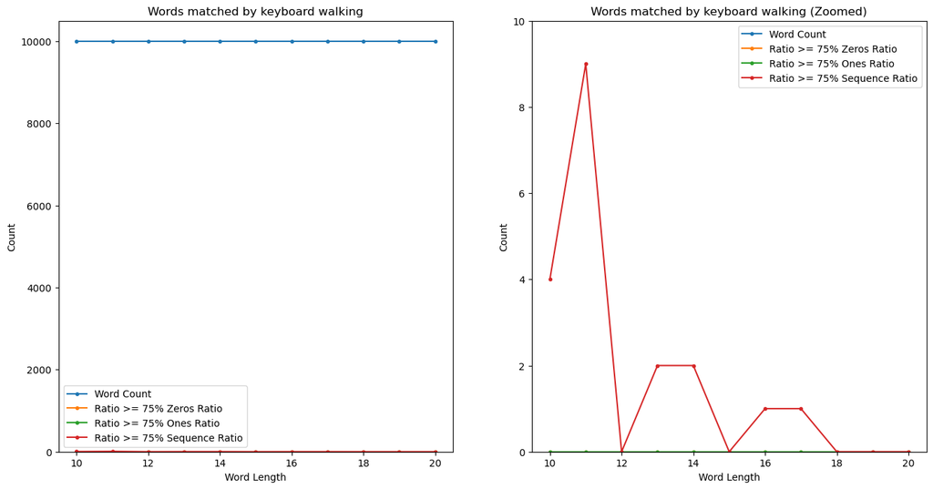

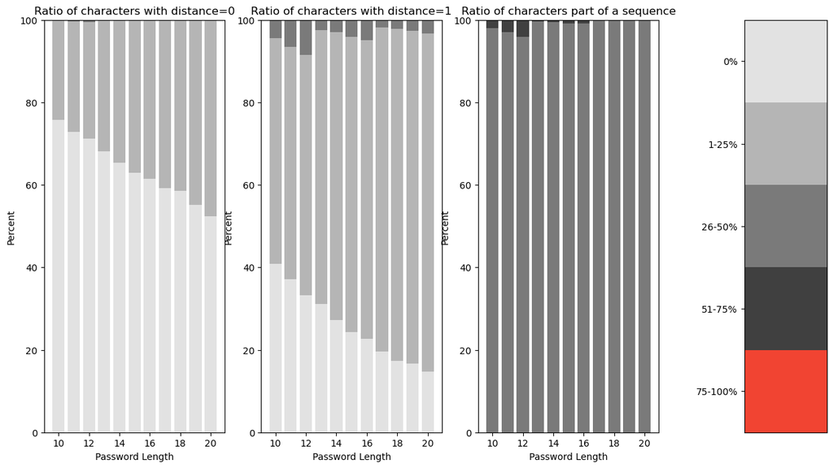

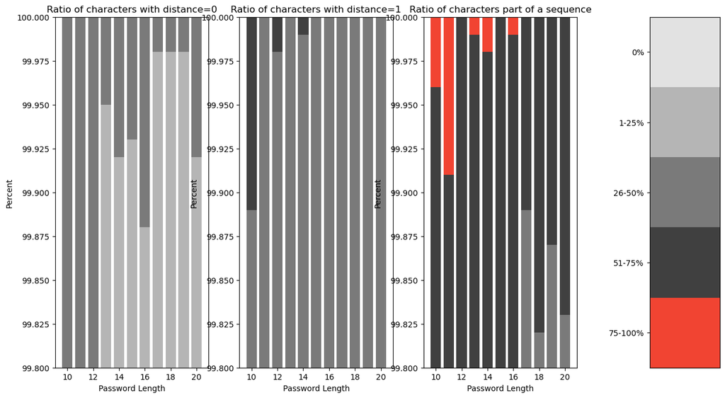

```python
tmp = pandas.read_csv('wordlists/results/keepassxc.txt_results', sep='|', on_bad_lines='skip', encoding_errors='ignore')
keepass = tmp[tmp['zeros-ratio'].notna() & tmp['ones-ratio'].notna() & tmp['seq-ratio'].notna()]
print(len(keepass))
graph_words(keepass, zoom=(0, 10), threshold=.75)
bargraph_results(keepass)
bargraph_results(keepass, ylim=(99.8,100))
k2 = keepass[(keepass['seq-ratio'] >= .75)]
```

```python
keepass[(keepass['seq-ratio'] >= .75)]
```

|  | word | distances | word-len | dist-len | zeros-ratio | ones-ratio | seq-ratio |
| --- | --- | --- | --- | --- | --- | --- | --- |
| 4101 | MFLJ9YSezu | 4,5,2,4,4,5,2,4,8 | 10 | 9 | 0.00 | 0.00 | 0.89 |
| 4907 | 3wdSCzqWXV | 2,2,1,2,2,2,1,2,2 | 10 | 9 | 0.00 | 0.22 | 0.89 |
| 5194 | XCU5dKJWC4 | 1,6,3,4,5,1,6,3,4 | 10 | 9 | 0.00 | 0.22 | 0.89 |
| 6391 | Z3DZmRYMEc | 5,2,3,6,5,2,3,6,2 | 10 | 9 | 0.00 | 0.00 | 0.89 |
| 10859 | U3FznbVezNm | 5,3,4,5,1,1,3,4,5,1 | 11 | 10 | 0.00 | 0.30 | 0.80 |
| 11529 | SeNjRuW37HF | 2,5,2,4,3,5,2,4,3,2 | 11 | 10 | 0.00 | 0.00 | 0.80 |
| 13262 | XrHVirS399j | 4,3,3,6,4,3,3,6,0,4 | 11 | 10 | 0.10 | 0.00 | 0.80 |
| 13563 | LafrHsReA3o | 8,3,1,3,4,3,1,3,4,7 | 11 | 10 | 0.00 | 0.20 | 0.80 |
| 15288 | sV47E9DH7oN | 3,3,3,5,7,8,3,3,3,5 | 11 | 10 | 0.00 | 0.00 | 0.80 |
| 17628 | bn92eRghzYN | 1,6,7,2,1,2,1,6,7,2 | 11 | 10 | 0.00 | 0.30 | 0.80 |
| 18882 | JPkqLmV9cAs | 4,3,8,9,3,3,8,9,3,1 | 11 | 10 | 0.00 | 0.10 | 0.80 |
| 19136 | y3SrfZvS4D4 | 4,3,3,1,4,3,3,4,3,3 | 11 | 10 | 0.00 | 0.10 | 0.90 |
| 19739 | 2cskWzFEowx | 4,2,6,7,3,4,2,6,7,2 | 11 | 10 | 0.00 | 0.00 | 0.80 |
| 33718 | 7hfhnxesFXwrK | 3,2,2,1,4,3,2,2,3,2,2,5 | 13 | 12 | 0.00 | 0.08 | 0.75 |
| 36306 | 4WVRzMLYneoT2 | 3,4,2,5,6,3,4,2,5,6,4,4 | 13 | 12 | 0.00 | 0.00 | 0.83 |
| 45184 | cMD3fj5RmUrC4w | 4,5,2,3,3,4,2,5,2,3,3,4,3 | 14 | 13 | 0.00 | 0.00 | 0.77 |
| 45659 | WVVM73c5TnChdM | 4,0,3,3,4,3,5,1,3,3,4,3,5 | 14 | 13 | 0.08 | 0.08 | 0.77 |
| 61160 | 5iivD2yPPNgEiNhz | 4,0,6,2,3,5,4,0,6,2,3,5,4,1,6 | 16 | 15 | 0.13 | 0.07 | 0.80 |
| 75094 | MFiR7pty2fMortLMW | 4,5,4,4,4,5,1,5,4,4,4,5,1,5,3,7 | 17 | 16 | 0.00 | 0.12 | 0.75 |

### A review of false-postives

None of these appear to be keyboard patterns to me. It's likely some consideration for the direction of flow added as an additional consideration could prevent false-positives. This is something that will be investigated in the future.

| | | | | :-:|:-:|:-:|:-:

[figure not shown]

|

[figure not shown]

|

[figure not shown]

|

[figure not shown]

|

[figure not shown]

|

[figure not shown]

|

[figure not shown]

|

[figure not shown]

|

[figure not shown]

|

[figure not shown]

|

[figure not shown]

|

[figure not shown]

|

[figure not shown]

| |